# Ford GoBike System Data Analysis

## by Abdallah Aboudeif

## Investigation Overview

> In general, Ford GoBike System Data Analysis aims to identify the most prominent user segments, their characteristics, and the extent to which their use relates to specific days during the week.

## Dataset Overview

> The given dataset represent data for bicycle trips that customers made during a period of the year 2019, trips data are the data related to trips date and time and its duration, and the customer's data, which are gender, year of birth, type of subscription, and also the bike number.

## The distribution of members type

> The percentage of customers for each type of subscription

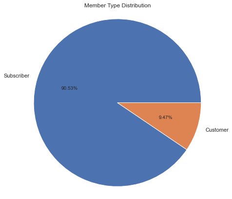

## The distribution of members age

> What ages customers are? and what is the number of customers in every age?

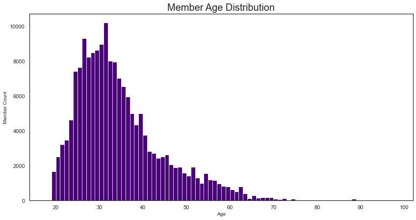

## The distribution of members gender

> What is the percentage of males and females customers?

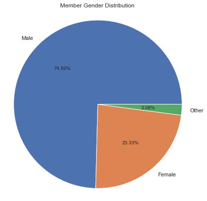

## The distribution of trip durations

> Logarithmic scale for number of trips compared to trip durations

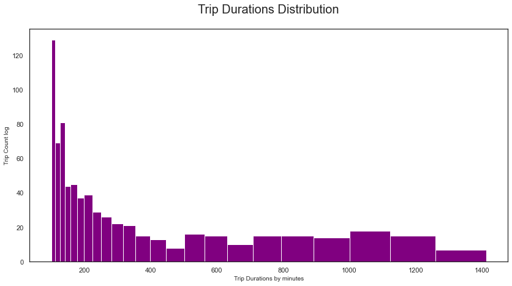

## The distribution of trips number week days

> The number of trips for every day of the week

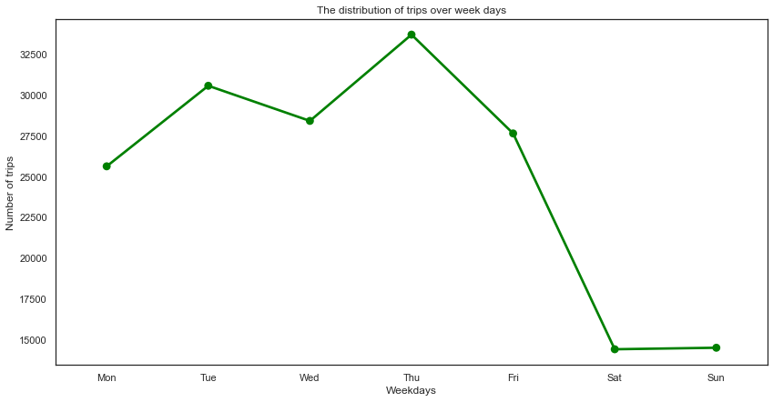

## The distribution of trips changes over the week days according to user type

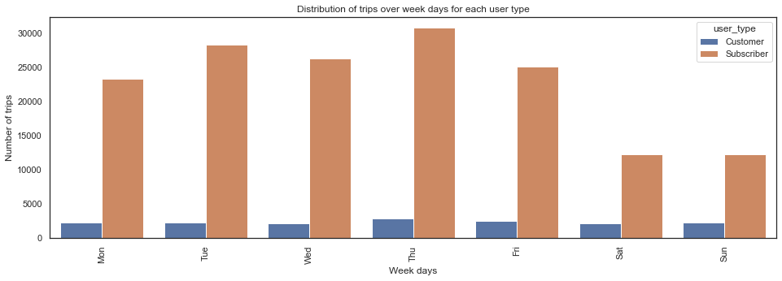

## The relationship between the percentages of male and female users for each day of the week

> The number of trips for males and females customers on every day of the week

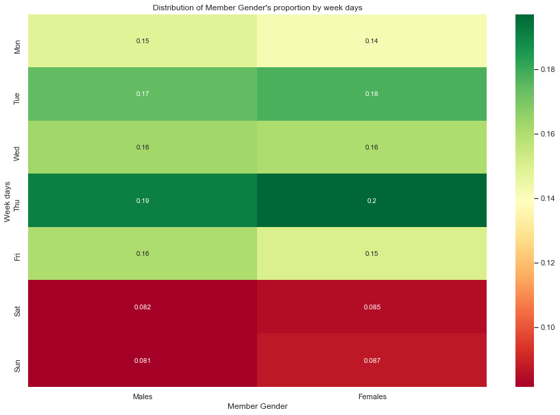

## The distribution of trips duration spent by every member age over week days

> Trips duration for every customer age on every day of the week

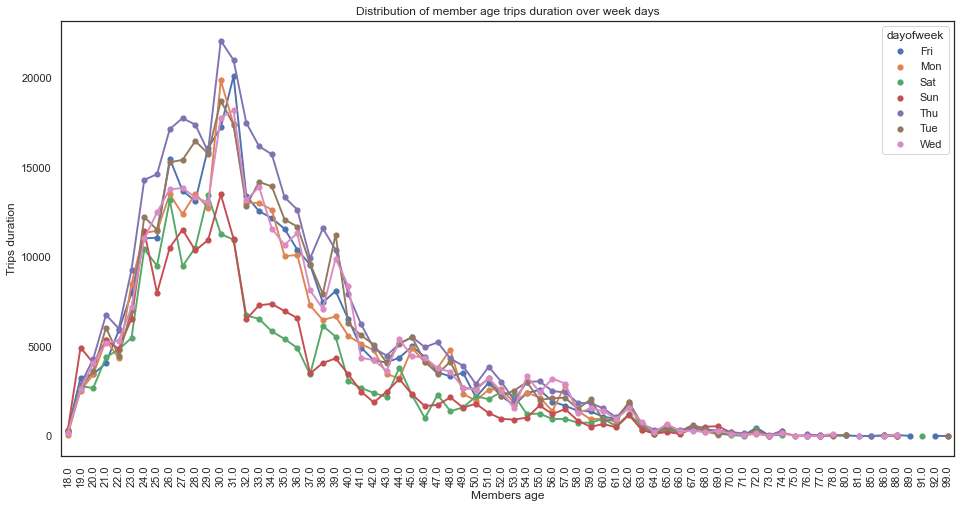

## The distribution of trips duration spent by every member gender over week days

> Trips duration spent by every member gender over week days

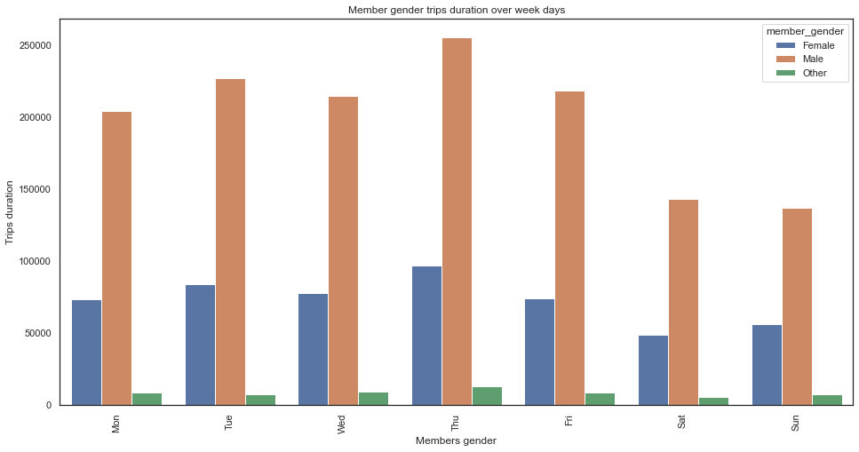

## The distribution of trips duration compared to trips numbers over week days

> Trips duration compared to number of trips over week days

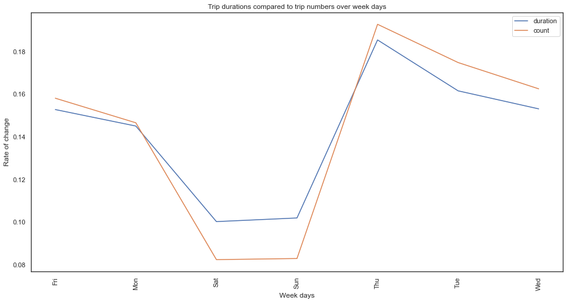

## Summary

> The largest segment of customers in terms of gender is the male customers by 75%. As for the type of user, the largest percentage of customers is the subscribers by 90%, and for the common age group it is the youth between 20 and 42 years old.

> Although Thursdays and Tuesdays are the days with the largest total trip durations, trips on Saturdays and Sundays have a higher rate of duration than the rest of week days compared to the number of trips, while the duration rate decreases on the rest of week days compared to the average number of trips.